# RepData_PeerAssessment1

## By Tristan Ficarro on October 14, 2019

First let’s load and view the data.

```r
rawdat <- read.csv("activity.csv")
str(rawdat)
```

```
## 'data.frame':    17568 obs. of  3 variables:
##  $ steps   : int  NA NA NA NA NA NA NA NA NA NA ...
##  $ date    : Factor w/ 61 levels "2012-10-01","2012-10-02",..: 1 1 1 1 1 1 1 1 1 1 ...
##  $ interval: int  0 5 10 15 20 25 30 35 40 45 ...
```

I notice some NA values. Let’s see how many there are.

```r
sum(is.na(rawdat$steps))
```

```
## [1] 2304
```

So we see that there are 2304 missing values. It may be good to investigate why, but for now I will simply exclude them.

```r
dat <- rawdat[!(is.na(rawdat$steps)), ]
str(dat)
```

```
## 'data.frame':    15264 obs. of  3 variables:
##  $ steps   : int  0 0 0 0 0 0 0 0 0 0 ...
##  $ date    : Factor w/ 61 levels "2012-10-01","2012-10-02",..: 2 2 2 2 2 2 2 2 2 2 ...
##  $ interval: int  0 5 10 15 20 25 30 35 40 45 ...
```

Now that we have excluded the missing values, let’s look at some plots.

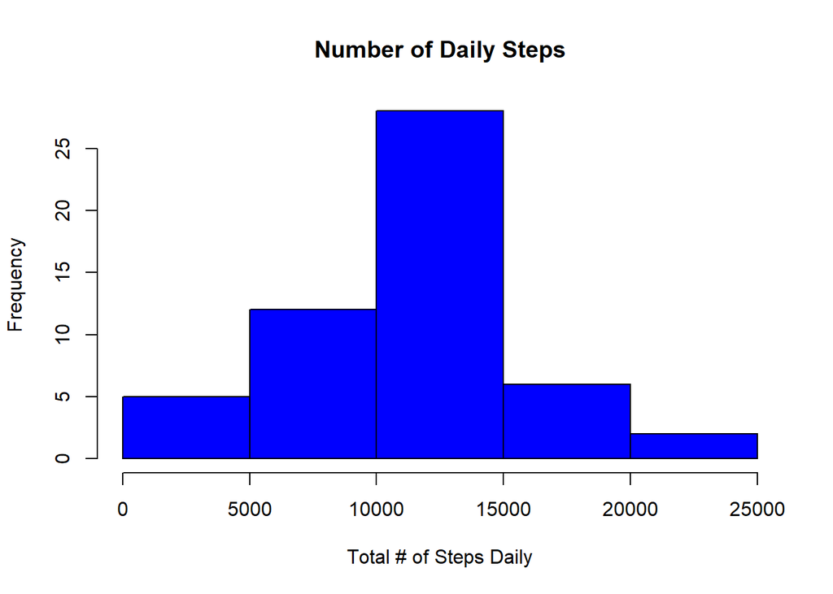

```r
datAgg <- aggregate(dat$steps,by = list(dat$date), sum)
names(datAgg) <- c("Date", "Steps")
hist(datAgg$Steps, col = "blue1", xlab = "Total # of Steps Daily", main = "Number of Daily Steps")
```

And now some summary data, including the mean and median.

```r
summary(datAgg$Steps)
```

```
##    Min. 1st Qu.  Median    Mean 3rd Qu.    Max.
##      41    8841   10765   10766   13294   21194
```

Let’s look at a time series plot of the mean steps for each 5-minute interval.

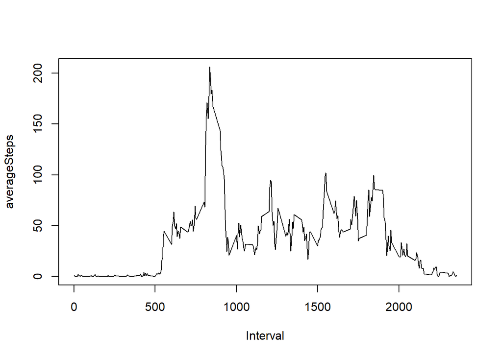

```r
datTS <- aggregate(dat$steps,by = list(dat$interval), mean)
names(datTS) <- c("Interval", "averageSteps")
with(datTS, plot(Interval, averageSteps, type = "l"))
```

The 5-minute interval with the most steps, on average, is 835.

```r
sum(is.na(rawdat$steps))
```

```
## [1] 2304
```

Let’s create a new data frame where we impute all missing values with the mean for that interval. Remember, we have stored the average steps per interval in the datTS data frame. We will store this new steps value in the newSteps column and use the mutate function with some ifelse logic.

```r
library(dplyr)
datFilled <- mutate(merge(datTS, rawdat, by.x = "Interval", by.y = "interval"), newSteps = ifelse(is.na(steps), averageSteps, steps))
head(datFilled)
```

```
##   Interval averageSteps steps       date newSteps
## 1        0     1.716981    NA 2012-10-01 1.716981
## 2        0     1.716981     0 2012-11-23 0.000000
## 3        0     1.716981     0 2012-10-28 0.000000
## 4        0     1.716981     0 2012-11-06 0.000000
## 5        0     1.716981     0 2012-11-24 0.000000
## 6        0     1.716981     0 2012-11-15 0.000000
```

Let’s look at a histogram and some summary data of our new data frame.

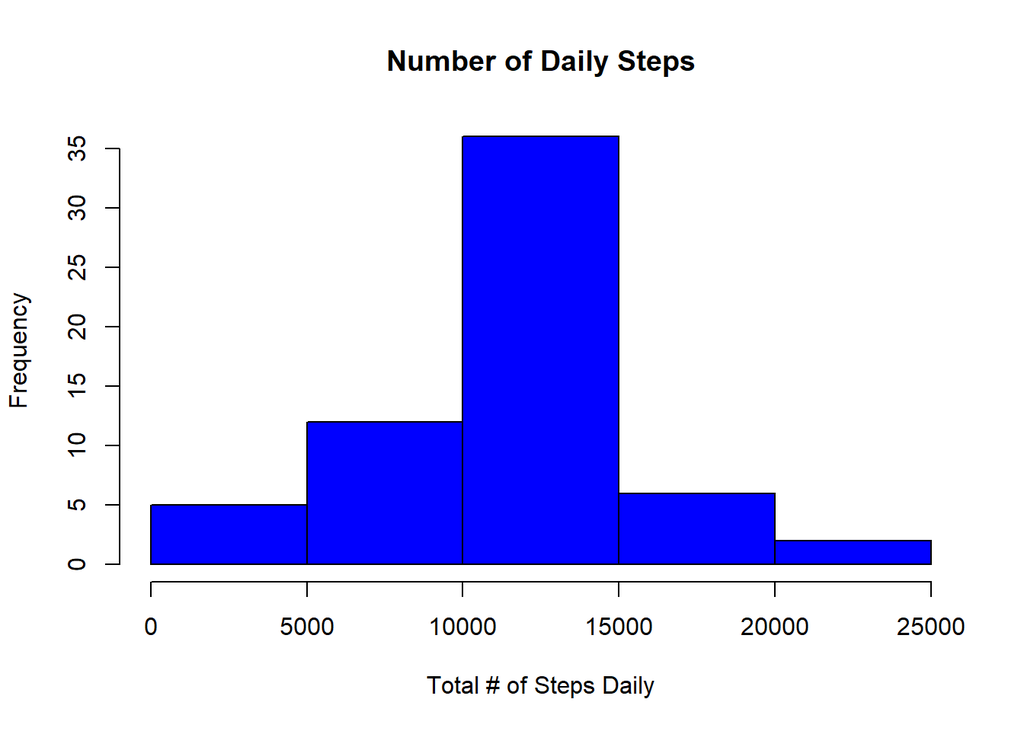

```r
datAggFilled <- aggregate(datFilled$newSteps,by = list(datFilled$date), sum)
names(datAggFilled) <- c("Date", "Steps")
hist(datAggFilled$Steps, col = "blue1", xlab = "Total # of Steps Daily", main = "Number of Daily Steps")
```

```r
summary(datAggFilled$Steps)
```

```
##    Min. 1st Qu.  Median    Mean 3rd Qu.    Max.
##      41    9819   10766   10766   12811   21194
```

Compared to our values above, we see that the histogram has a higher peak for the middle level of 10000-15000 daily steps. This is supported by the fact that the first quartile is higher, while the third quartile is lower. Our data is now stronger at the peak of the histogram.

The mean and median of our two data frames do not vary by much. The median for the new data set jumped 1 step.

Let’s add a factor variable to our data frame to specify whether it is a weekday or now

```r
library(chron)
datFilled <- mutate(datFilled, dayFactor = as.factor(ifelse(is.weekend(as.Date(datFilled$date)), "Weekend", "Weekday")))
head(datFilled)
```

```
##   Interval averageSteps steps       date newSteps dayFactor
## 1        0     1.716981    NA 2012-10-01 1.716981   Weekday
## 2        0     1.716981     0 2012-11-23 0.000000   Weekday
## 3        0     1.716981     0 2012-10-28 0.000000   Weekend
## 4        0     1.716981     0 2012-11-06 0.000000   Weekday
## 5        0     1.716981     0 2012-11-24 0.000000   Weekend
## 6        0     1.716981     0 2012-11-15 0.000000   Weekday
```

Now let’s look at a plot separated by our new factor variable.

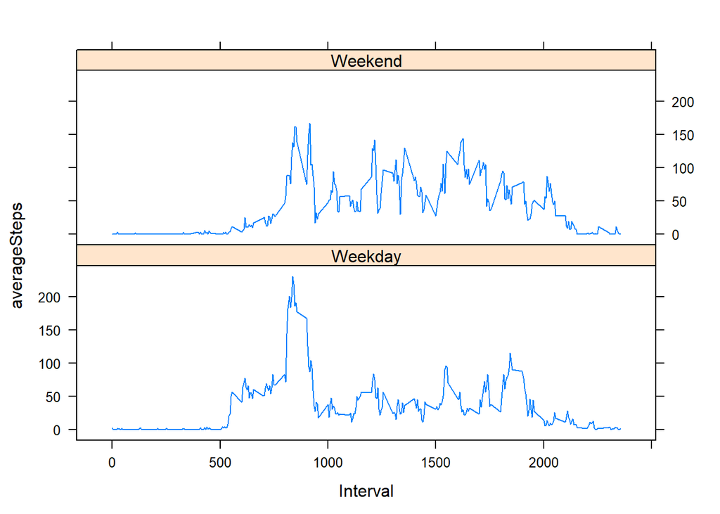

```r
library(lattice)
datTSFilled <- aggregate(datFilled$newSteps,by = list(datFilled$Interval, datFilled$dayFactor), mean)
names(datTSFilled) <- c("Interval", "dayFactor", "averageSteps")
with(datTSFilled, xyplot(averageSteps ~ Interval | dayFactor, type = "l", layout = c(1,2)))
```